# CMSC 320 Fall 2018 Final Tutorial:

## Understanding Movie Revenue, Genre, and Ratings through Data Analysis

### By: Will Davis, Ryan Kendig, Greg Hare

## Introduction and Background

As a group of cinephiles, we decided to perform analysis on data on movies and movie reviews. There are many different aspects to investigate in regards to movie data, so we decided to start with a broad analysis goal, and once we gain some insight, we narrowed down some specific relationships to investigate. We found two different datasets collected from IMDB, and a large dataset of seperate user reviews.

### Datasets we used:

https://www.kaggle.com/carolzhangdc/imdb-5000-movie-dataset https://www.kaggle.com/PromptCloudHQ/imdb-data/data https://grouplens.org/datasets/movielens/

First import the following libraries that we'll be using throughout this tutorial:

# Part 0: Get Data

```python
import pandas as pd
import numpy as np
import IPython.display
import re

pd.set_option('display.max_rows', 500)
pd.set_option('display.max_columns', 500)

meta1 = pd.read_csv("IMDB-Movie-Data.csv")
links = pd.read_csv("ml-latest-small/links.csv")
movies = pd.read_csv("ml-latest-small/movies.csv")
ratings = pd.read_csv("ml-latest-small/ratings.csv")
tags = pd.read_csv("ml-latest-small/tags.csv")
meta2 = pd.read_csv("movie_metadata.csv")
```

# Part 1: Clean up, Tidy, and Merge Data

### 1.1 Lets clean up the movies data from movies.csv

```python
#what it looks like before
movies.head()
```

|  | movieId | title | genres |
| --- | --- | --- | --- |
| 0 | 1 | Toy Story (1995) | Adventure\|Animation\|Children\|Comedy\|Fantasy |
| 1 | 2 | Jumanji (1995) | Adventure\|Children\|Fantasy |
| 2 | 3 | Grumpier Old Men (1995) | Comedy\|Romance |
| 3 | 4 | Waiting to Exhale (1995) | Comedy\|Drama\|Romance |
| 4 | 5 | Father of the Bride Part II (1995) | Comedy |

```python
#Extract the year from the title column
year, title1, title_length = [], [], []
for i in range (len(movies)):
    title = movies['title'][i][0:-7]
    year.append(movies['title'][i][-5:-1])
    title1.append(title)
    title_length.append(len(title.split()))
movies['title'] = title1
movies['title_length'] = title_length
movies['year'] = year

#change some of the titles to not have (blah..) in the middle
reg = re.compile('\(.*\)')
movies['title'] = movies['title'].str.replace(reg,'',regex=True)

#change some of the titles to not have have form: 'Movie Title, The'
movies['title'] = movies['title'].map(lambda x: str(x)).map(lambda x: x if ',' not in x else x[x.rfind(',') + 1:] + " " + x[:x.rfind(',')])

#merge movies with links to get the imdb id's
movies = movies.merge(links, how='inner', on='movieId')

movies["genres"] = (movies["genres"].map(lambda x: str(x))).map(lambda x: x if x == 'NaN' else x.replace('|', ','))
movies.drop(axis=1,inplace=True,columns=['tmdbId'])
```

```python
#Now it looks a little nicer
movies.head()
```

|  | movieId | title | genres | title_length | year | imdbId |
| --- | --- | --- | --- | --- | --- | --- |
| 0 | 1 | Toy Story | Adventure,Animation,Children,Comedy,Fantasy | 2 | 1995 | 114709 |
| 1 | 2 | Jumanji | Adventure,Children,Fantasy | 1 | 1995 | 113497 |
| 2 | 3 | Grumpier Old Men | Comedy,Romance | 3 | 1995 | 113228 |
| 3 | 4 | Waiting to Exhale | Comedy,Drama,Romance | 3 | 1995 | 114885 |
| 4 | 5 | Father of the Bride Part II | Comedy | 6 | 1995 | 113041 |

### 1.2 Now, lets merge movies.csv with ratings.csv

This creates a master table of user reviews and movie data which we'll call the "ml_table" since we got it from 'ml-latest-smallest'

```python
#merge movies with ratings to create our master review table
ml_table = ratings.merge(movies,on="movieId")
display(ml_table.head())
```

|  | userId | movieId | rating | timestamp | title | genres | title_length | year | imdbId |
| --- | --- | --- | --- | --- | --- | --- | --- | --- | --- |
| 0 | 1 | 1 | 4.0 | 964982703 | Toy Story | Adventure,Animation,Children,Comedy,Fantasy | 2 | 1995 | 114709 |
| 1 | 5 | 1 | 4.0 | 847434962 | Toy Story | Adventure,Animation,Children,Comedy,Fantasy | 2 | 1995 | 114709 |
| 2 | 7 | 1 | 4.5 | 1106635946 | Toy Story | Adventure,Animation,Children,Comedy,Fantasy | 2 | 1995 | 114709 |
| 3 | 15 | 1 | 2.5 | 1510577970 | Toy Story | Adventure,Animation,Children,Comedy,Fantasy | 2 | 1995 | 114709 |
| 4 | 17 | 1 | 4.5 | 1305696483 | Toy Story | Adventure,Animation,Children,Comedy,Fantasy | 2 | 1995 | 114709 |

The ml_table could use some final touching up, so lets go ahead and finish up some tidying we neglected to do earlier

```python
ml_table['datetime'] = pd.to_datetime(ml_table['timestamp'],unit='s')
ml_table.drop(axis=1,inplace=True,columns=['timestamp'])
display(ml_table.head())
```

|  | userId | movieId | rating | title | genres | title_length | year | imdbId | datetime |
| --- | --- | --- | --- | --- | --- | --- | --- | --- | --- |
| 0 | 1 | 1 | 4.0 | Toy Story | Adventure,Animation,Children,Comedy,Fantasy | 2 | 1995 | 114709 | 2000-07-30 18:45:03 |
| 1 | 5 | 1 | 4.0 | Toy Story | Adventure,Animation,Children,Comedy,Fantasy | 2 | 1995 | 114709 | 1996-11-08 06:36:02 |
| 2 | 7 | 1 | 4.5 | Toy Story | Adventure,Animation,Children,Comedy,Fantasy | 2 | 1995 | 114709 | 2005-01-25 06:52:26 |
| 3 | 15 | 1 | 2.5 | Toy Story | Adventure,Animation,Children,Comedy,Fantasy | 2 | 1995 | 114709 | 2017-11-13 12:59:30 |
| 4 | 17 | 1 | 4.5 | Toy Story | Adventure,Animation,Children,Comedy,Fantasy | 2 | 1995 | 114709 | 2011-05-18 05:28:03 |

### 1.3 Tidy up and create an IMBD movie dataset

This dataset has all of the meta data about our movies, and is a combination of 2 imdb datasets. These datasets we named meta1 and meta 2. Becuase we are combining these two sets and they have similar but not exactly matching data and formats, some values are missing

```python
# For meta2, extract the imbd movie ids from inside the link and put into a new column
regex = re.compile(r"\/tt(\d+)")
ids = []
for i in range (len(meta2)):
    match = re.search(regex, meta2['movie_imdb_link'][i])
    ids.append(match.group(1))
meta2['IMDB_ID'] = ids
```

```python
#Drop columns we dont need
meta2.drop(axis=1, inplace=True, columns=['num_user_for_reviews', 'movie_imdb_link', 'num_critic_for_reviews', 'movie_facebook_likes','director_facebook_likes','actor_3_facebook_likes','actor_1_facebook_likes','actor_2_facebook_likes','color','aspect_ratio','cast_total_facebook_likes','facenumber_in_poster'])
meta1.drop(axis=1, inplace=True,columns=['Rank'])
```

```python
#format some of the columns
    # Year column
meta2["Year"] = meta2["title_year"].map(lambda x: str(x)).map(lambda x: 0 if x == 'NaN' else x[:4])
meta2.drop(axis=1,columns=['title_year'], inplace=True)
    # duration column
meta2["Runtime (Minutes)"] = meta2['duration'].map(lambda x: str(x)).map(lambda x: 0 if x == 'NaN' else x[:4])
meta2.drop(axis=1,columns=['duration'], inplace=True)
    # Actor column
meta2['Actors'] = meta2['actor_1_name'] + ', ' + meta2['actor_2_name'] + ', ' + meta2['actor_3_name']
meta2.drop(axis=1, inplace=True,columns=['actor_1_name', 'actor_2_name', 'actor_3_name'])
    # gross column
meta2["Revenue (Millions)"] = meta2["gross"].map(lambda x: str(x)).map(lambda x: 0 if x == 'NaN' else float(x)/1000000)
meta2.drop(axis=1, inplace=True,columns=['gross'])
    # genre column
meta2["Genre"] = (meta2["genres"].map(lambda x: str(x))).map(lambda x: x if x == 'NaN' else x.replace('|', ','))
meta2.drop(axis=1,columns=['genres'], inplace=True)
    # title column
meta2["Title"] = (meta2["movie_title"].map(lambda x: str(x))).map(lambda x: x if x == 'NaN' else x.replace(u'\xa0', u''))
meta2.drop(axis=1,columns=['movie_title'], inplace=True)
    # Rename some columns
meta2.rename(columns={'director_name' : 'Director', 'imdb_score' : 'Rating'}, inplace=True)


imdb_table = pd.concat([meta1, meta2], axis=0, sort=False, join='outer') #The magic

#Drop duplicate movies
imdb_table.drop_duplicates(subset='Title', keep="last", inplace=True)

display(imdb_table.head())
```

|  | Title | Genre | Description | Director | Actors | Year | Runtime (Minutes) | Rating | Votes | Revenue (Millions) | Metascore | num_voted_users | plot_keywords | language | country | content_rating | budget | IMDB_ID |
| --- | --- | --- | --- | --- | --- | --- | --- | --- | --- | --- | --- | --- | --- | --- | --- | --- | --- | --- |
| 2 | Split | Horror,Thriller | Three girls are kidnapped by a man with a diag... | M. Night Shyamalan | James McAvoy, Anya Taylor-Joy, Haley Lu Richar... | 2016 | 117 | 7.3 | 157606.0 | 138.12 | 62.0 | NaN | NaN | NaN | NaN | NaN | NaN | NaN |
| 3 | Sing | Animation,Comedy,Family | In a city of humanoid animals, a hustling thea... | Christophe Lourdelet | Matthew McConaughey,Reese Witherspoon, Seth Ma... | 2016 | 108 | 7.2 | 60545.0 | 270.32 | 59.0 | NaN | NaN | NaN | NaN | NaN | NaN | NaN |
| 5 | The Great Wall | Action,Adventure,Fantasy | European mercenaries searching for black powde... | Yimou Zhang | Matt Damon, Tian Jing, Willem Dafoe, Andy Lau | 2016 | 103 | 6.1 | 56036.0 | 45.13 | 42.0 | NaN | NaN | NaN | NaN | NaN | NaN | NaN |
| 6 | La La Land | Comedy,Drama,Music | A jazz pianist falls for an aspiring actress i... | Damien Chazelle | Ryan Gosling, Emma Stone, Rosemarie DeWitt, J.... | 2016 | 128 | 8.3 | 258682.0 | 151.06 | 93.0 | NaN | NaN | NaN | NaN | NaN | NaN | NaN |
| 7 | Mindhorn | Comedy | A has-been actor best known for playing the ti... | Sean Foley | Essie Davis, Andrea Riseborough, Julian Barrat... | 2016 | 89 | 6.4 | 2490.0 | NaN | 71.0 | NaN | NaN | NaN | NaN | NaN | NaN | NaN |

#### Lets talk about our master movie meta data dataframe:

We have over 5000 movies that have data on everything from the director of the movie to its runtime and revenue. There are definitely some holes that must be addressed however. First off, there are many more than 5000 movies in existence, so this is only a taste. We are also missing some data. Much of it is no doubt due the limits on our data quantity, but some of it may be missing not at random. In particular, there are some movies that do not have data on revenue. It could be missing at random and be dependant on the movies imdb rating, or the data could be missing not at random because the revenue was low and thus was not reported. Also, analysis on the relationship between budget and gross revenue can't really be explored because we only have budget data for a few number of movies. Like wise, many relationships could not be explore fully due to large sums of missing data.

# Part 2: Data Exploration and Visualization

```python
import matplotlib.pyplot as plt
import seaborn as sns
import sklearn
from sklearn import linear_model
from sklearn.linear_model import LinearRegression
from sklearn.model_selection import train_test_split
```

## 2.1: Quick visualization using plots

### 2.1.1: imdb rating vs metascore rating

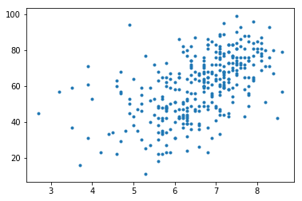

```python
x = imdb_table['Rating']
y = imdb_table['Metascore']
plt.plot(x, y, '.')
plt.xticks(rotation='horizontal')
```

### 2.1.2: Year vs Revenue

This plot made clear that over time maximum revenues have tended to increase in a somewhat linear fashion.  
However, minimum revenues have obviously stayed consistent near 0, and average revenues may or may not be increasing linearly, but it is difficult to tell due to density of graph.

```python
noo = imdb_table

noo = noo[noo['Year'] != 'nan']
noo = noo[noo['Revenue (Millions)'].notnull()]

noo['YearInt'] = pd.to_numeric(noo['Year'])
noo['YearBin'] = (noo['YearInt'] / 10).astype(int) * 10


s = []
for i in range(1900, 2018):
    m = noo.where(noo['YearInt'] == i)['Revenue (Millions)'].mean()
    s.append({'Year':i, 'Mean Revenue (Millions)':m})

mean_revs = pd.DataFrame(s)
```

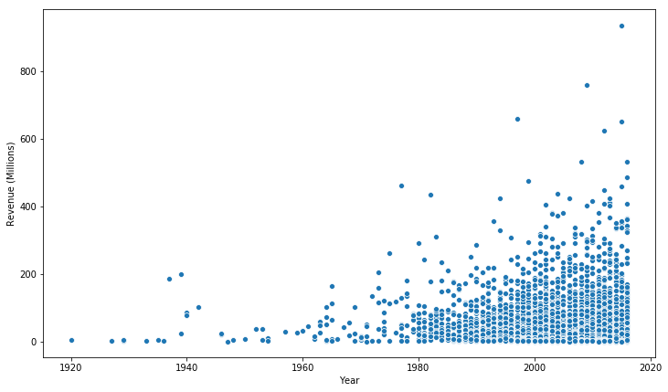

```python
plt.subplots(figsize=(12,7))
ax = sns.scatterplot(x=imdb_table['Year'], y=imdb_table['Revenue (Millions)'])
plt.show()
```

### 2.1.3: Year vs Mean Revenue

Here we plot the mean revenues for each year, which proved to be a rather erratic trendline.  
There is a massive spike around 1940, which is most likely caused by an extremely small sample size of films from that time period.

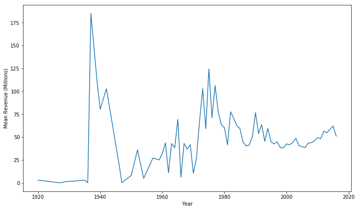

```python
plt.subplots(figsize=(12,7))

ax = sns.lineplot(x=mean_revs['Year'], y=mean_revs['Mean Revenue (Millions)'])
plt.show()
```

### 2.1.4: Decade vs Revenue Violin

The violin plots contrast the story told by the plot of mean revenues. While the mean values led us to believe that movie revenues were varying wildly over the years, these violin plots, with boxplots inside, show that the median revenues and the revenues for most films have stayed fairly consistent over the past century.  
They also do an excellent job of highlighting how the maximum revenues of the decade have been steadily increasing since the 1980s, showing the ever-growing disparity between the highest-grossing blockbusters and the "average" movie revenue.

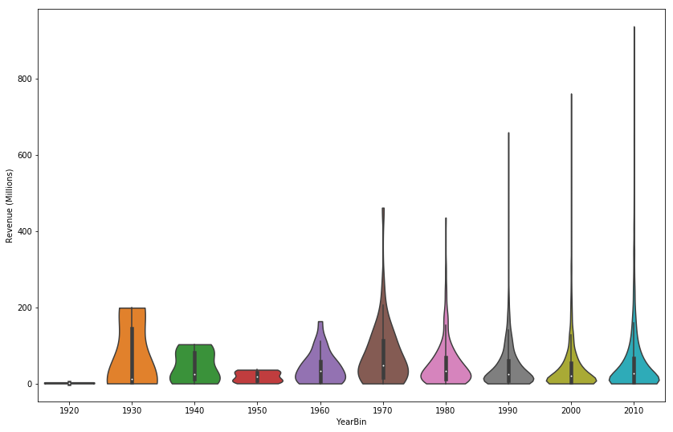

```python
plt.subplots(figsize=(14,9))

ax = sns.violinplot(x=noo['YearBin'], y=noo['Revenue (Millions)'], scale='width', cut=0)
plt.show()
```

### Plot 2.1.5 Rating vs Revenue Plot

Comparing revenue against ratings provided some very interesting trends.  
Though a high rating does not guarantee a high revenue, a very low rating seems to be tied with low revenue.  
We can't be sure whether low rating leads to lower revenues, or whether lower attendance/revenue contributed to lower ratings, but we would hypothesize the former.  
Additionally, the highest revenues appear to increase as rating increases to 8, and then revenues seem to taper off some above that. This could be because "high art" very-highly rated films are not necessarily blockbusters or interest only a niche crowd, thus having modest revenues in spite of a high rating.  
Because of this, the relationship is not purely linear, and the relationship may be better described by a higher power function.

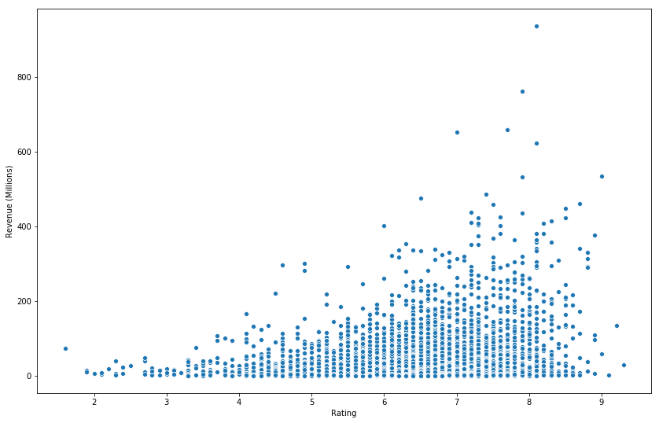

```python
plt.subplots(figsize=(14,9))

ax = sns.scatterplot(x=imdb_table['Rating'], y=imdb_table['Revenue (Millions)'])
plt.show()
```

### 2.1.6: Ratings for null Revenue values

This box plot provides the distribution of ratings for movies that did not have a listed revenue.

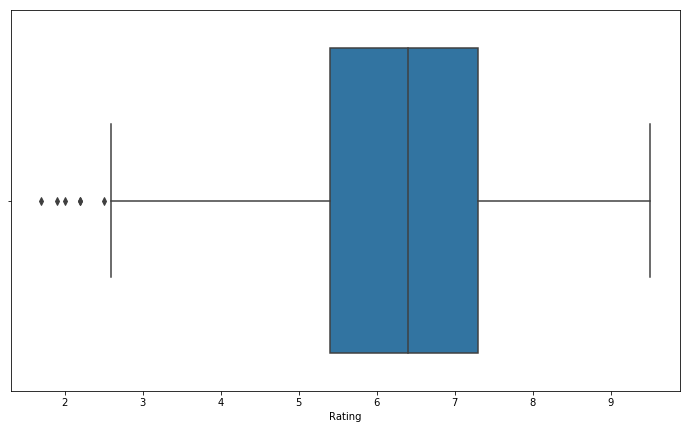

```python
rev = imdb_table.sort_values(ascending=True, by='Revenue (Millions)')

revNAN = rev.loc[rev['Revenue (Millions)'].isnull()]

plt.subplots(figsize=(12,7))

sns.boxplot(data=revNAN, x='Rating')
plt.show()
```

### 2.1.7: Violin Plot of Ratings over Years

This plot mostly just illustrates that the distributions of movie ratings have not changed significantly over the years, aside from a slightly larger range of ratings in the more recent years.

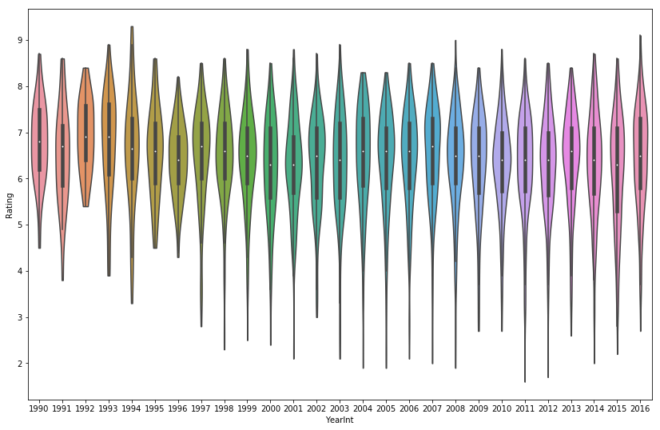

```python
years = imdb_table
years = years[years['Year'] != 'nan']
years['YearInt'] = pd.to_numeric(years['Year'])
years_ord = years.sort_values(ascending=True, by='YearInt')
since1990 = years_ord.loc[years_ord.YearInt.astype(int) >= 1990]

plt.subplots(figsize=(14,9))

ax = sns.violinplot(x=since1990['YearInt'], y=since1990['Rating'], cut=0)
#ax.set(yscale="log")
plt.show()
```

## Part 2.2: In-depth visualizing of trends accross Genre

There are a lot of ways in which movies can differ accross genre. For instance the average budget for an action/adventure movie will most likely be much higher than the average budget for a documentary. To split our data by genre, we will have to do some manipulating.

First, we will convert our genre column into a workable version:

```python
#Reset index
imdb_table = imdb_table.reset_index()
#Convert genre column into a column of arrays
genre_list = imdb_table['Genre'].map(lambda x: x.split(','))
imdb_table['Genre'] = genre_list

all_genres = []

#list of all genre tags from every movie
for i in range(len(genre_list)):
    all_genres = all_genres + genre_list[i]

#list of all unique genres
all_genres = pd.DataFrame(data=all_genres, columns={'genre'}).genre.unique()
```

all_genres

Now we'll define a few functions to help our analysis. The first filters our data into the chunks where a given genre occurs, the second will be used to plot relevant data about genres.

```python
#Takes a list of genres, and a dataframe of movie entries
#Returns dataframe with only movies that include genre tags in genres parameter
def filter_by_genre(genres, df):
    if len(genres) > 0 :
        line = df['Genre'].map(lambda x: True if genres[0] in x else False )
        return filter_by_genre(genres[1:], df[line])
    else :
        return df

#Takes a list of genres, a table, x param and y param
#Plots features for movies with genres in genres param
def plot_genre_attributes(genres, table, xIn, yIn):
    genre_df = filter_by_genre(genres, table)
    sns.scatterplot(x=xIn, y=yIn, data=genre_df)
    string = ''.join( x + " " for x in genres)

    plt.title(string + " movies: " + yIn + " vs. " + xIn)
    plt.xlabel(xIn)
    plt.ylabel(yIn)
    plt.show()
```

For the previous point, now we can try and see the difference in average movie budget between action/adventure and documentary movies

```python
action = filter_by_genre(['Action', 'Adventure'], imdb_table)
documentary = filter_by_genre(['Documentary'], imdb_table)
action_avg = np.sum(action['budget'])/len(action)
doc_avg = np.sum(documentary['budget'])/len(documentary)

print("Average budget for an Action/Adventure Movie: $", action_avg)
print("Average budget for a Documentary: $", doc_avg)
print("Average difference: $", action_avg-doc_avg)
```

```
Average budget for an Action/Adventure Movie: $ 83054732.4706
Average budget for a Documentary: $ 3764913.46281
Average difference: $ 79289819.0078
```

As we can see this confirms our hypothesis proposed above that the average budget for an Action/Adventure movie is greater than the budget for a documentary. In fact there is a difference of nearly 80 million dollars.

To further analyze budget information relative to genre, we can utilyze the second function defined above:

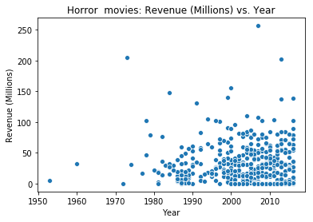

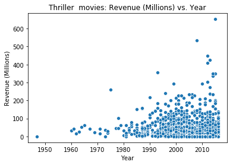

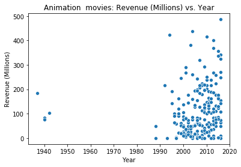

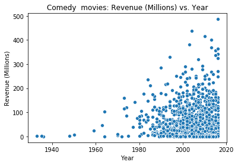

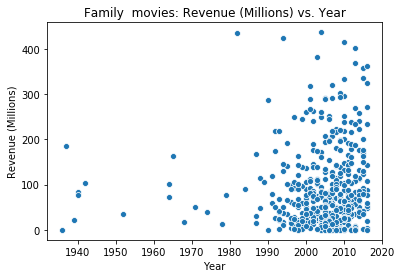

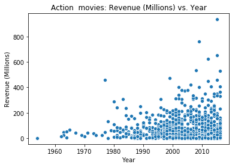

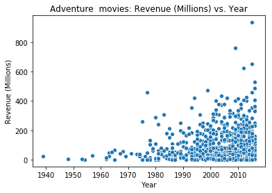

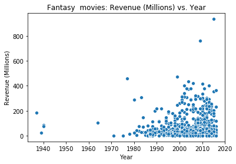

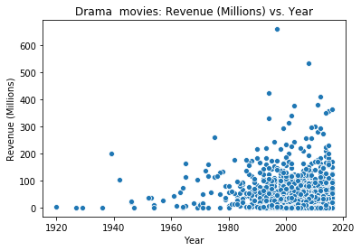

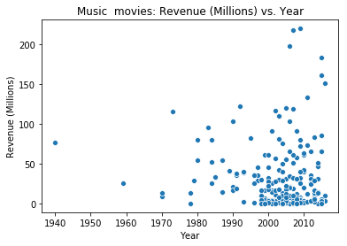

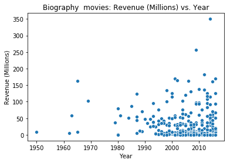

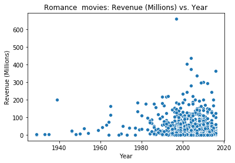

[14 more figures not shown]

```python
for x in all_genres:
    plot_genre_attributes([x], imdb_table, 'Year','Revenue (Millions)')
```

From these plots it is obvious that Fantasy, Action, and Adventure movies have the highest overall revenue.

## Part 2.3 Comparing User Ratings to IMDB ratings

Now lets look at how user ratings compare to IMDB ratings. First lets do it for just one movie: Toy Story

```python
#get all user ratings for the movie Toy Story
toy_story = ml_table[ml_table['title'] == "Toy Story"]
toy_story['rating'].map(lambda x: x * 2).sum() / len(toy_story) #average them (multiply by 2 bc user ratings are out of 5 not 10)
#We get 7.8418604651162793

imdb_table.loc[imdb_table['Title'] == 'Toy Story'].Rating
#Looking it up in our IMDB table, we get 8.3
```

```
1892    8.3
Name: Rating, dtype: float64
```

Now lets do it for all the movies

(The following code we ran once and then saved to the file 'user_ratings.csv')

```python
user_ratings_avg = pd.read_csv("user_ratings.csv",sep='\t') #get the average user ratings for each movie
user_ratings_avg.drop(columns=['Unnamed: 0'],inplace=True) #drop an unneeded column

#Some columns got switched. Switch them back. THIS WAS HARD SUPER TO FIGURE OUT
ary=np.where(user_ratings_avg['title'].str.contains('\d+\.\d+',regex=True),[user_ratings_avg.avg_rating,user_ratings_avg.title],[user_ratings_avg.title,user_ratings_avg.avg_rating])
pd.DataFrame({'title':ary[0],'avg_rating':ary[1]}).head()
```

|  | title | avg_rating |
| --- | --- | --- |
| 0 | Toy Story | 7.84186046512 |
| 1 | Grumpier Old Men | 6.51923076923 |
| 2 | Heat | 7.89215686275 |
| 3 | Seven | 7.95073891626 |
| 4 | The Usual Suspects | 8.47549019608 |

```python
user_ratings_avg = user_ratings_avg.merge(movies,how='inner', on='title') #this gets more info about each movie, including imdbID
```

```python
#Make sure both imdb Ids are in string format for easy merging
user_ratings_avg['IMDB_ID'] = user_ratings_avg['imdbId'].map(lambda x: str(x))
imdb_table['IMDB_ID'] = imdb_table['IMDB_ID'].map(lambda x: str(x))

#Merge first on imdb_ID, then on Title to get any stragglers
new = user_ratings_avg.merge(imdb_table[['IMDB_ID','Rating']],how="inner",on='IMDB_ID')
new2 = user_ratings_avg.merge(imdb_table[['Title','Rating']],how='inner',left_on='title',right_on='Title')
```

```python
#concatenate the two tables, and get rid of duplicates
user_ratings_avg = pd.concat([new,new2],axis=0,join='inner')
user_ratings_avg.drop_duplicates(subset='title', keep="first", inplace=True)
user_ratings_avg.drop_duplicates(subset='IMDB_ID', keep="first", inplace=True)

#Drop any columns we don't need
user_ratings_avg.drop(axis=1, inplace=True, columns=['imdbId'])
#Turn the avg_rating column to numeric values
user_ratings_avg.avg_rating = user_ratings_avg.avg_rating.astype(float)
```

Lets plot the average user's rating vs the IMDB rating. Each point represents a movie

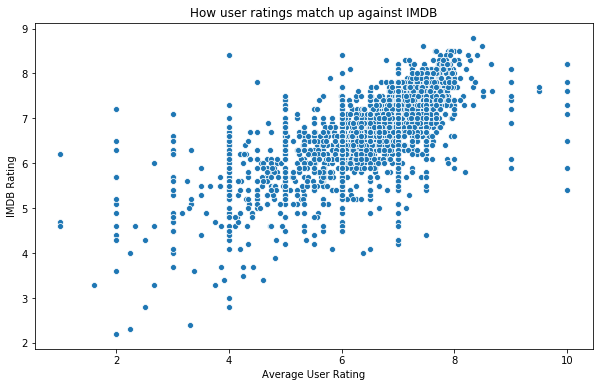

```python
plt.subplots(figsize=(10,6))
ax = sns.scatterplot(x='avg_rating', y='Rating', data=user_ratings_avg)
ax.set(xlabel='Average User Rating', ylabel='IMDB Rating', title='How user ratings match up against IMDB',)
# ax.set_xscale('linear')
plt.show()
```

# Part 3: Analysis, Hypothesis testing, & ML

## 3.1: User Rating vs imdb rating

Now, lets create a linear model of user rating vs imbd rating. We can use this model to predict a imdb rating based on the average user rating. Or on the flip side, we can hypothesize what the average viewer will rate a movie based on what IMDB rated.

```python
#This model will use user ratings as the x values, and imdb as the y

model1 = LinearRegression()
X = user_ratings_avg[['avg_rating']]
y = user_ratings_avg[["Rating"]]
X_train, X_test, y_train, y_test = train_test_split(X, y)
model1.fit(X_train, y_train)

print(model1.coef_)
print(model1.intercept_)
```

```
[[ 0.51088875]]
[ 3.36873691]
```

Now the have a model, lets see that previous scatterplot again this time with a linear regression line. Reminder, each point represents a different movie

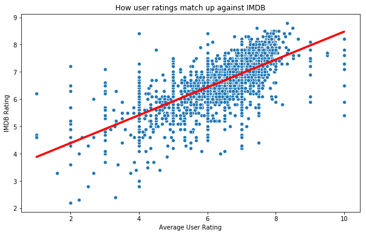

```python
plt.subplots(figsize=(10,6))
ax = sns.scatterplot(x='avg_rating', y='Rating', data=user_ratings_avg)
ax.set(xlabel='Average User Rating', ylabel='IMDB Rating', title='How user ratings match up against IMDB',)
plt.plot(X_test, model1.predict(X_test), color='red', linewidth=3)
plt.show()
```

From the above plot, we can see that the average user rating of a movie is less than the imdb rating for the same movie. This holds true for the lower range of values, but it appears that as movie ratings increase, the two ratings agree more and more. Users and imdb critics alike seem to agree that good movies are good movies. It is important to note, however, that there are several user ratings of value 10, a ratings that is nonexistent among imdb ratings. This may skew our model, but in there definitely appears to be a linear relationship though, and with a coeficient of ~.5, we can see the relations is fairly strong. We can explore this more via a plot of the residuals.

```
[Text(0,0.5,'Residual'),
 Text(0.5,0,'User Rating'),
 Text(0.5,1,'Scatter Plot of Residuals')]
```

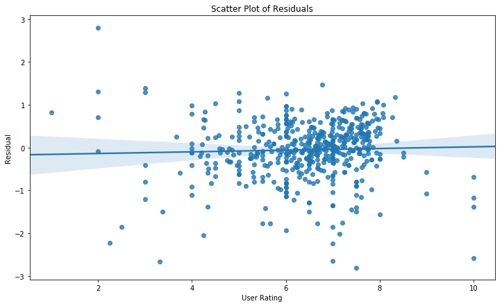

```python
residual_df = pd.concat([X_test,(y_test - model1.predict(X_test))], axis=1) #calculate the residual df
plt.subplots(figsize=(12,7))
ax = sns.regplot(data=residual_df,x='avg_rating',y='Rating')
ax.set(xlabel='User Rating', ylabel='Residual', title='Scatter Plot of Residuals')
#plt.show()
```

This scatterplot shows the difference between predictions. We can see that there is no visual trend between ratings and residuals which is good. This shows that a linear model is indeed the best type of model to represent this relationship. In agreement with the above plot, we can see the residuals are very small when dealing with movies that users rated in the 5-7 range. It appears although people may have different ideas about what makes a bad and great movie, they agree upon which movies are just 'good'. It may be also that 5-7 is a very middle of the road rating and there are alot of movies with ratings of 5-7 by both imdb and the average user.

## 3.2 LinReg of Year vs Revenue

From performing a linear regression on the relationship between Year and Revenue, it again appears that there is a slight positive correlation between the two. However, the score of the regression is extremely low, so the predictive power is fairly abysmal.

```python
#Some data tidying
noo = imdb_table

noo = noo[noo['Year'] != 'nan']
noo = noo[noo['Revenue (Millions)'].notnull()]
noo = noo[noo['Rating'].notnull()]

noo['YearInt'] = pd.to_numeric(noo['Year'])
```

```python
reg = LinearRegression()
x = noo[['YearInt']]
y = noo[['Revenue (Millions)']]
x_train, x_test, y_train, y_test = train_test_split(x,y)
reg.fit(x_train, y_train)
#display(reg.predict(1980))
display(reg.coef_)
display(reg.intercept_)
display(reg.score(x,y))
```

```
array([[ 0.13215651]])
```

```
array([-217.56663583])
```

```
0.0002329158753430205
```

## 3.3 Linear Regression of Rating vs Revenue

```python
reg = LinearRegression()
x = noo[['Rating']]
y = noo[['Revenue (Millions)']]
x_train, x_test, y_train, y_test = train_test_split(x,y)
reg.fit(x_train, y_train)
#display(reg.predict(10))
display(reg.coef_)
display(reg.intercept_)
display(reg.score(x,y))
```

```
array([[ 13.86236514]])
```

```
array([-42.44884574])
```

```
0.03794443511832235
```

## 3.4: Market Basket Analysis

To understand how genres are assigned to movies throughout our data, we can use a technique called "market basket analysis," where essentially the correlation value between sets of values are computed. First enter the following command in your terminal to download the libraries needed:

pip install mlxtend

We will need to import the following libraries:

```python
from mlxtend.frequent_patterns import apriori
from mlxtend.frequent_patterns import association_rules
```

Now we need to "1-hot-encode" our genre data so that it can be processed. In other words we are creating columns in our dataset for every genre variable and filling the columns with 1 where the genre tag appears, and 0 where it does not.

```python
#Instantiate matrix of 0's
genres = pd.DataFrame(data=genre_list)
for x in all_genres:
    genres[x] = 0
del genres['Genre']

#assign genre columns to one where they appear in a movie
for i in range(len(genre_list)):
    for j in genre_list[i]:
        genres[j][i] = 1
```

```python
frequent_genre_sets = apriori(genres, min_support=0.07, use_colnames=True)
rules = association_rules(frequent_genre_sets, metric="lift", min_threshold=0)
```

Now we have our table of association values for all our genres:

```python
rules.sort_values(by='lift', ascending=False)
```

|  | antecedents | consequents | antecedent support | consequent support | support | confidence | lift | leverage | conviction |
| --- | --- | --- | --- | --- | --- | --- | --- | --- | --- |
| 10 | (Action) | (Adventure) | 0.223861 | 0.178106 | 0.089998 | 0.402027 | 2.257241 | 0.050127 | 1.374468 |
| 11 | (Adventure) | (Action) | 0.178106 | 0.223861 | 0.089998 | 0.505308 | 2.257241 | 0.050127 | 1.568934 |
| 4 | (Thriller) | (Crime) | 0.274721 | 0.173757 | 0.103989 | 0.378527 | 2.178488 | 0.056255 | 1.329492 |
| 5 | (Crime) | (Thriller) | 0.173757 | 0.274721 | 0.103989 | 0.598477 | 2.178488 | 0.056255 | 1.806318 |
| 0 | (Thriller) | (Action) | 0.274721 | 0.223861 | 0.110418 | 0.401927 | 1.795433 | 0.048919 | 1.297733 |
| 1 | (Action) | (Thriller) | 0.223861 | 0.274721 | 0.110418 | 0.493243 | 1.795433 | 0.048919 | 1.431217 |
| 9 | (Comedy) | (Romance) | 0.369068 | 0.214974 | 0.115901 | 0.314037 | 1.460810 | 0.036561 | 1.144414 |
| 8 | (Romance) | (Comedy) | 0.214974 | 0.369068 | 0.115901 | 0.539138 | 1.460810 | 0.036561 | 1.369026 |
| 13 | (Drama) | (Romance) | 0.522405 | 0.214974 | 0.144262 | 0.276149 | 1.284567 | 0.031958 | 1.084513 |
| 12 | (Romance) | (Drama) | 0.214974 | 0.522405 | 0.144262 | 0.671064 | 1.284567 | 0.031958 | 1.451940 |
| 14 | (Drama) | (Crime) | 0.522405 | 0.173757 | 0.103800 | 0.198697 | 1.143535 | 0.013029 | 1.031125 |
| 15 | (Crime) | (Drama) | 0.173757 | 0.522405 | 0.103800 | 0.597388 | 1.143535 | 0.013029 | 1.186243 |
| 2 | (Thriller) | (Drama) | 0.274721 | 0.522405 | 0.134997 | 0.491397 | 0.940644 | -0.008519 | 0.939033 |
| 3 | (Drama) | (Thriller) | 0.522405 | 0.274721 | 0.134997 | 0.258415 | 0.940644 | -0.008519 | 0.978011 |
| 6 | (Drama) | (Comedy) | 0.522405 | 0.369068 | 0.134052 | 0.256605 | 0.695279 | -0.058751 | 0.848717 |
| 7 | (Comedy) | (Drama) | 0.369068 | 0.522405 | 0.134052 | 0.363217 | 0.695279 | -0.058751 | 0.750012 |

# Part 4: Major Takeaways

In this tutorial we took a broad approach, attacking our data from multiple angles and analyzing many different features of movies. Our goal was to get a general sense of which features of movies seem to interact, and see if we could build accurate models to predict different features. One feature we were able to predict was the official IMDB movie rating, based off of the average MovieLens user rating. It was interesting to see the relationship between user ratings and imdb ratings. We hypothesized that user ratings would not match up with critics ratings, but what we found was that for average movies (those with ratings 5-7) users and critics mostly agreed. The interesting part was the it appears as though users rate movies much extreme that critics near the end of the rating spectrum. That is, users tended to give poor movies a much lower score than imdb, and they tended to good great movies much higher ratings than imdb did.

We also showed through linear regression that revenue and rating are correlated with a coefficient of about 13 (million). However looking at the plot of revenue vs rating, we can see that revenue increases as rating increases until rating gets into the 8.0 - 10.0 range, where revenue starts to decrease. This is perhaps because of the low marketability and low consumer demand of highly technical artistic films which typically recieve such high ratings. We could perhaps consult some domain experts on the topic to confirm or disconfirm this hypothesis.

Thanks for taking the time to follow our tutorial, we hope you learned something about movies, and at the very least learned how some general techniques to analyze data!

p.s. we don't need data to show that Shrek III was by far the greatest movie ever made